# Point Loma Abalone Tag Analysis

Kevin L. Stierhoff

October 18, 2016

```r
# Horizontal position error (unitless) threshold for data filtering
max.HPE <- 7.5
# Calculated distance (m) threshold for data filtering
max.DIST <- 20
# Calculated speed (m/s) threshold for data filtering
max.SPEED <- 0.2
# Minimum number of detections for convex hull plots
min.DETECT <- 100
```

```r
if(import.data==TRUE){
  ab.files <- dir("../Data/VPS-PtLoma-01-Results-20160817/Positions/ab_tags",full.names = TRUE)
  sync.files <- dir("../Data/VPS-PtLoma-01-Results-20160817/Positions/sync_tags",full.names = TRUE)
  # create temporary data frames for pre-processed tag data
  ab.res <- data.frame()
  sync.res <- data.frame()
  # read all abalone transmitter files
  for(i in ab.files){
    # read file i
    temp <- read.csv(i)
    # convert DATETIME to POSIXct
    temp$DATETIME <- as.POSIXct(as.character(temp$DATETIME),format = "%Y-%m-%d %H:%M:%S") #"2015-11-13 22:00:19"
    # calculate the time interval between detections, in seconds
    temp$INTERVAL <- c(0,as.numeric(difftime(temp$DATETIME[2:nrow(temp)],temp$DATETIME[1:nrow(temp)-1],units = 'secs')))
    # calculate Euclidian distance between detections, in meters
    temp$DISTANCE <- c(0,sqrt(((temp$X[2:nrow(temp)]-temp$X[1:nrow(temp)-1])^2)+((temp$Y[2:nrow(temp)]-temp$Y[1:nrow(temp)-1])^2)))
    # calculate movement speed between detections
    temp$SPEED <- temp$DISTANCE/temp$INTERVAL
    # add data to temporary data frame
    ab.res <- rbind(ab.res,temp)
  }
  # create factor for tag type
  ab.res$TYPE <- as.factor("PINTO")
  # save results to .Rdata file
  save(ab.res,file="../Data/abalone_data.Rdata")

  # read all sync tag files
  for(i in sync.files){
    temp <- read.csv(i)
    # convert DATETIME to POSIXct
    temp$DATETIME <- as.POSIXct(as.character(temp$DATETIME),format = "%Y-%m-%d %H:%M:%S") #"2015-11-13 22:00:19"
    # calculate the time interval between detections
    temp$INTERVAL <- c(0,as.numeric(difftime(temp$DATETIME[2:nrow(temp)],temp$DATETIME[1:nrow(temp)-1],units = 'secs')))
    # calculate Euclidian distance between detections
    temp$DISTANCE <- c(0,sqrt(((temp$X[2:nrow(temp)]-temp$X[1:nrow(temp)-1])^2)+((temp$Y[2:nrow(temp)]-temp$Y[1:nrow(temp)-1])^2)))
    # add data to temporary data frame
    sync.res <- rbind(sync.res,temp)
  }
  # create factor for tag type
  sync.res$TYPE <- as.factor("SYNC TAG")
  # save results to .Rdata file
  save(sync.res,file="../Data/sync_data.Rdata")

  # read location summaries from Witting
  locations <- read.csv("../Data/tag_location_summary_DW.csv")
  save(locations,file="../Data/locations.Rdata")

  # read station info file
  station.data <- read.csv("../Data/stations.csv")
  save(station.data,file="../Data/stations.Rdata")
}else{
  # load previously procesSsed results
  load("../Data/sync_data.Rdata")
  load("../Data/abalone_data.Rdata")
  load("../Data/locations.Rdata")
  load("../Data/stations.Rdata")
}
```

```r
# create a sequence of dates to cut tag detections
cuts <- as.numeric(seq(floor_date(min(ab.res$DATETIME),"month"),ceiling_date(max(ab.res$DATETIME),"month"), "week"))
# create
cut.labels <- format(seq(floor_date(min(ab.res$DATETIME),"month"),ceiling_date(max(ab.res$DATETIME),"month"), "week"),"%m/%d/%Y")
# cut tag detections by time sequence
ab.res$CUT <- cut(as.numeric(ab.res$DATETIME),breaks = cuts,include.lowest=TRUE,labels=FALSE)
sync.res$CUT <- cut(as.numeric(sync.res$DATETIME),
                    breaks = seq(floor_date(min(sync.res$DATETIME),"month"),ceiling_date(max(sync.res$DATETIME),"month"),"week"),
                    include.lowest=TRUE,labels=FALSE)
```

```r
# subset abalone and sync data based on filters above
ab.res.sub <- ab.res %>%
  filter(HPE < max.HPE) %>%
  # remove weather events, as per D. Witting
  filter(DATETIME < as.Date("2015-12-08") | DATETIME > as.Date("2016-01-15")) %>%
  filter(DATETIME < as.Date("2016-02-01") | DATETIME > as.Date("2016-02-04")) %>%
  filter(DATETIME < as.Date("2016-03-05") | DATETIME > as.Date("2016-03-20"))
sync.res.sub <- sync.res %>%
  filter(HPE < max.HPE) %>%
  # remove weather events, as per D. Witting
  filter(DATETIME < as.Date("2015-12-08") | DATETIME > as.Date("2016-01-15")) %>%
  filter(DATETIME < as.Date("2016-02-01") | DATETIME > as.Date("2016-02-04")) %>%
  filter(DATETIME < as.Date("2016-03-05") | DATETIME > as.Date("2016-03-20"))
# summarize tag detections
# arrange(ddply(ab.res.sub,.(DETECTEDID),summarise,n=length(LON)),desc(n))
# get number of detections for each ab and sync tag
ab.tag.detections <- ab.res.sub %>%
  group_by(DETECTEDID) %>%
  summarise(N = length(X)) %>%
  arrange(desc(N))
# get list of tags with number of detections greater than min.DETECT
ab.tag.sub <- ab.tag.detections$DETECTEDID[ab.tag.detections$N > min.DETECT]
# filter tags with less than 150 detections
ab.res.final <- filter(ab.res.sub,DETECTEDID %in% ab.tag.sub)
ab.res.final$tag <- as.factor(substr(as.character(ab.res.final$DETECTEDID),12,14))
```

# Overview

Here I present a preliminary exploration of data from pinto abalone that were tagged and tracked at Pt. Loma between 2015-11-13 and 2016-05-17. The goal is to evaluate how to best filter the results to minimize positional errors and maximize information about movement distances, aggregation, etc.

For starters, filtered data consisted of a subset of abalone and sync tag data that had a horizontal position error (HPE) of $\leq$ 7.5, a speed between detections of $\leq$ 0.2 m/s, a computed distance between detections of $\leq$ 20 m. In addition, filtered results included only abalone tags with a minimum of 100 detections. This reduced the number of detections from 23116 to 3007 for abalone tags (87.0% of detections removed), and 146603 to 49376 for sync tags (66.3% of detections removed).

# Summary statistics

## Abalone tag data

**Table 1.** Summary of abalone tag data, where N is the number of detections and HPE is the horizontal position error (unitless). Filtered results include data from abalone tags that had $\geq$ 100 detections.

```r
ab.summ <- ab.res %>%
  group_by(DETECTEDID) %>%
  summarise(
      N = length(X),
      FirstRecord = format(min(DATETIME),format="%m/%d/%Y"),
      LastRecord = format(max(DATETIME),format="%m/%d/%Y"),
      MeanHPE = mean(HPE),
      MeanDistance = mean(DISTANCE),
      SdDistance = sd(DISTANCE)) %>%
  arrange(desc(N))
print(ab.summ)
```

| DETECTEDID | N | FirstRecord | LastRecord | MeanHPE | MeanDistance | SdDistance |
| --- | --- | --- | --- | --- | --- | --- |
| A69-1601-39438 | 4173 | 11/16/2015 | 02/05/2016 | 8.118931 | 6.228449 | 6.163750 |
| A69-1601-39418 | 3148 | 11/13/2015 | 02/19/2016 | 8.129574 | 4.849030 | 4.382732 |
| A69-1601-39428 | 2469 | 11/13/2015 | 01/17/2016 | 8.101985 | 4.778756 | 6.353605 |
| A69-1601-39446 | 2235 | 11/13/2015 | 03/02/2016 | 8.811857 | 6.964874 | 7.297931 |
| A69-1601-39426 | 1846 | 11/13/2015 | 05/09/2016 | 9.810293 | 2.125190 | 3.996726 |
| A69-1601-39423 | 1519 | 11/13/2015 | 01/07/2016 | 8.339631 | 11.155855 | 9.643544 |
| A69-1601-39445 | 1434 | 11/13/2015 | 03/16/2016 | 8.109484 | 5.491161 | 5.053857 |
| A69-1601-39424 | 1134 | 11/14/2015 | 02/22/2016 | 9.026014 | 6.637510 | 6.360306 |
| A69-1601-39420 | 968 | 11/13/2015 | 03/22/2016 | 8.880992 | 9.232642 | 7.302754 |
| A69-1601-39432 | 932 | 11/15/2015 | 12/30/2015 | 8.662554 | 7.685337 | 5.970859 |

[output cut: 20 more lines]

```r
write.csv(dplyr::select(ab.summ,DETECTEDID,FirstRecord,N,LastRecord),file="../Output/tag_summary_all.csv",quote = FALSE,row.names = FALSE)
ab.summ.filt <- ab.res.sub %>%
  group_by(DETECTEDID) %>%
  summarise(
      N = length(X),
      FirstRecord = format(min(DATETIME),format="%m/%d/%Y"),
      LastRecord = format(max(DATETIME),format="%m/%d/%Y"),
      MeanHPE = mean(HPE),
      MeanDistance = mean(DISTANCE),
      SdDistance = sd(DISTANCE)) %>%
  arrange(desc(N))
write.csv(dplyr::select(ab.summ.filt,DETECTEDID,FirstRecord,N,LastRecord),file="../Output/tag_summary_filtered.csv",quote = FALSE,row.names = FALSE)
```

## Sync tag data

**Table 2.** Suymmary of sync tag data, where N is the number of detections and HPEm is the horizontal position error (m).

```r
sync.summ <- ddply(sync.res,.(DETECTEDID),summarise,
      N = length(X),
      FirstRecord = min(DATETIME),
      LastRecord = max(DATETIME),
      MeanHPEm = mean(HPEm,na.rm=TRUE),
      MeanDistance = mean(DISTANCE),
      SdDistance = sd(DISTANCE))
print(sync.summ)
```

| DETECTEDID | N | FirstRecord | LastRecord | MeanHPEm | MeanDistance | SdDistance |
| --- | --- | --- | --- | --- | --- | --- |
| A69-1601-65045 | 19974 | 2015-11-13 23:20:50 | 2016-06-22 17:08:23 | 7.483063 | 9.582994 | 11.984625 |
| A69-1601-65042 | 23022 | 2015-11-13 22:08:11 | 2016-06-22 17:00:26 | 1.524451 | 1.677150 | 2.166211 |
| A69-9002-16318 | 15380 | 2016-02-04 18:28:31 | 2016-06-22 17:04:22 | 1.335228 | 1.584696 | 1.900314 |
| A69-1601-65040 | 21008 | 2015-11-13 22:07:54 | 2016-06-22 17:09:53 | 3.098295 | 3.625005 | 5.936451 |
| A69-1601-65041 | 19780 | 2015-11-13 22:22:07 | 2016-06-22 17:05:45 | 5.138874 | 3.609733 | 5.916205 |
| A69-1601-65044 | 13093 | 2015-11-13 22:33:44 | 2016-06-22 17:06:56 | 14.259352 | 14.167221 | 15.334424 |
| A69-1601-65039 | 20280 | 2015-11-13 22:47:15 | 2016-06-22 17:07:37 | 6.934112 | 7.867057 | 9.081394 |
| A69-1601-65043 | 14066 | 2015-11-17 18:10:18 | 2016-06-22 17:06:07 | 18.924676 | 17.669691 | 17.315364 |

# Summary plots

## Abalone tag data

### Abalone tag detections over time

Histograms of abalone tag detections by weekly (7-d) bins, from the earliest to the latest detection of any tag. **NOTE differenes in y-axis scale.**

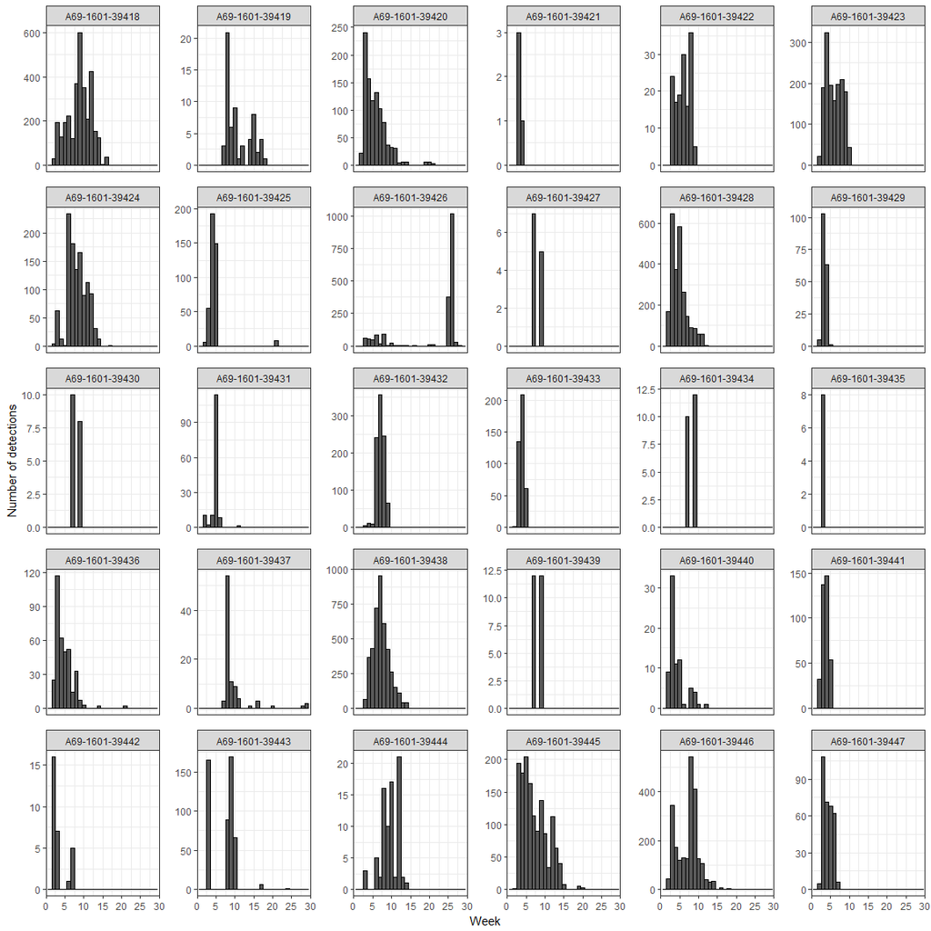

```r
ggplot(ab.res,aes(CUT)) + geom_histogram(binwidth=1,colour='black') +
  scale_x_continuous("Week",breaks = seq(0,30,5),limits = c(0,30),expand=c(0,0)) +
  scale_y_continuous("Number of detections") +
    # scale_y_continuous("Number of detections",breaks = seq(0,1200,300),limits = c(0,1200),expand = c(0,0)) +
  facet_wrap(~DETECTEDID,scales="free_y") +
  theme_bw() +
  theme(panel.spacing=unit(1, "lines"))
```

### Abalone tag horizontal position error (HPE) - FILTERED

Histograms of abalone tag horizontal position error (HPE; unitless), filtered to include only detections with HPE $\leq$ 7.5. **NOTE differenes in y-axis scale.**

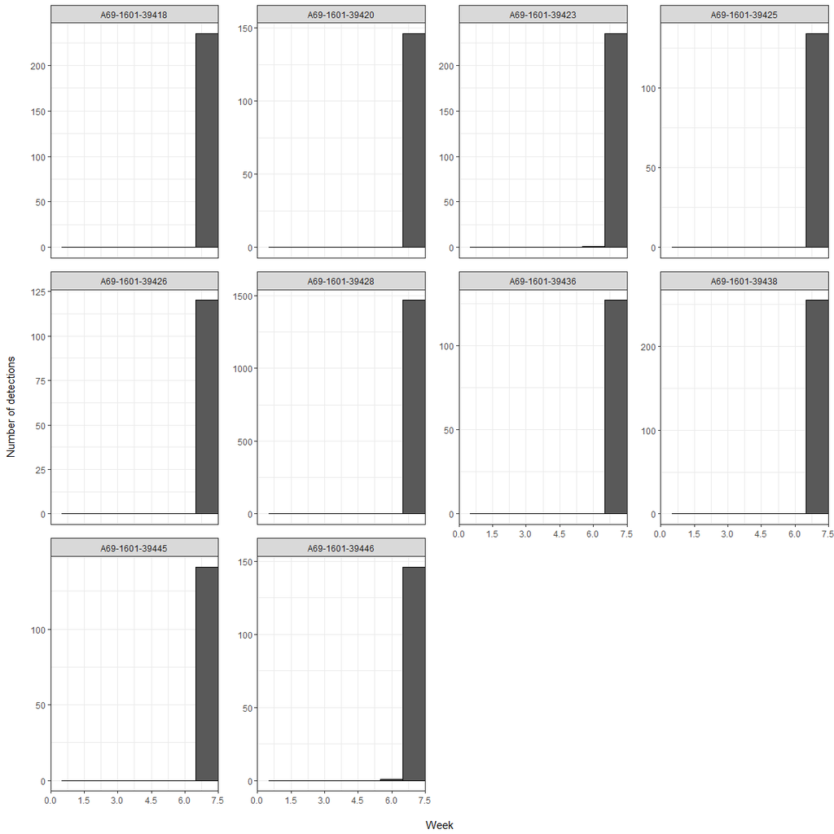

```r
ggplot(ab.res.final,aes(HPE)) + geom_histogram(binwidth=1,colour='black') +
  scale_x_continuous("\nWeek",breaks = seq(0,max.HPE,max.HPE/5),limits = c(0,max.HPE),expand=c(0,0)) +
  scale_y_continuous("Number of detections\n") +
  facet_wrap(~DETECTEDID,scales="free_y") +
  theme_bw() +
  theme(panel.spacing=unit(1, "lines"))
```

### Abalone tag movement distances between detections

Most abalone movements were less than 20 m between detections. **NOTE differenes in y-axis scale.**

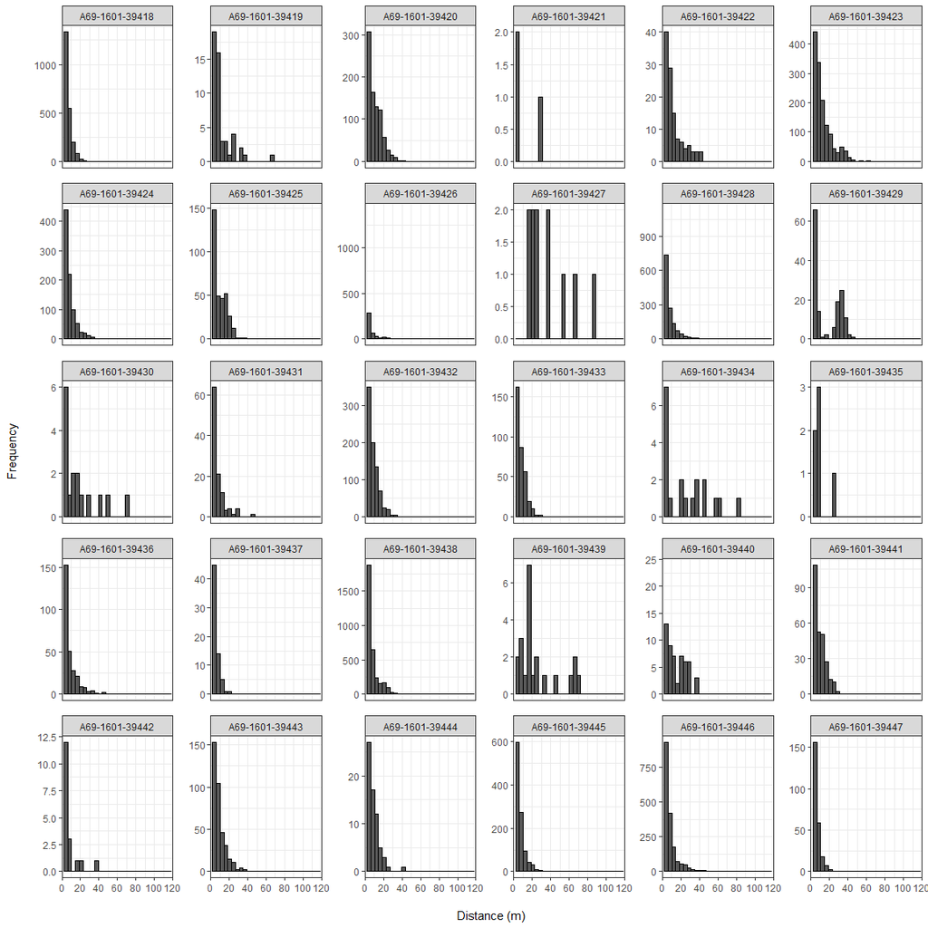

```r
ggplot(ab.res,aes(DISTANCE)) +
  geom_histogram(bins = 30,colour = "black") +
  scale_x_continuous("\nDistance (m)",limits=c(0,120),breaks = seq(0,120,20),expand=c(0,0)) +
  scale_y_continuous("Frequency\n") +
  # scale_y_continuous("Frequency\n",limits = c(0,1500),breaks = seq(0,1500,300),expand=c(0,0)) +
  facet_wrap(~DETECTEDID,scales="free_y") +
  theme_bw() +
  theme(panel.spacing=unit(1, "lines"))
```

### Abalone tag movement speed between detections

The vast majority of abalone speeds appears to be less than 0.2 m/s, which could serve as a first pass cut-off for filtering. **NOTE differenes in y-axis scale.**

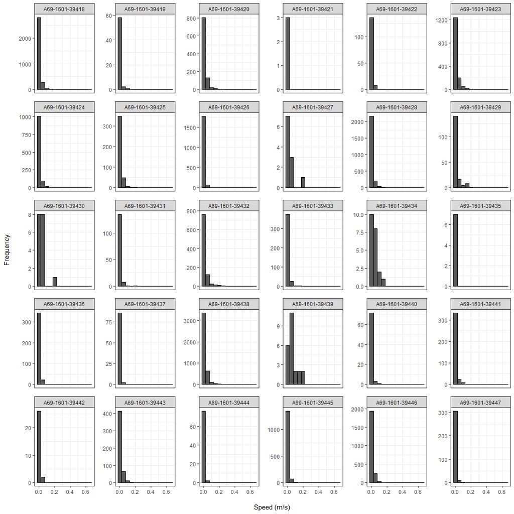

```r
ggplot(ab.res,aes(SPEED)) +
  geom_histogram(binwidth = 0.05,colour = "black") + facet_wrap(~DETECTEDID,scales="free_y") +
  scale_x_continuous("\nSpeed (m/s)") +
    # scale_x_continuous("\nSpeed (m/s)",limits=c(-0.2,1),breaks = seq(-0.2,1,0.2),expand=c(0,0)) +
  scale_y_continuous("Frequency\n") +
    # scale_y_continuous("Frequency\n",limits = c(0,150),breaks = seq(0,150,30),expand=c(0,0)) +
  theme_bw() +
  theme(panel.spacing=unit(1, "lines"))
```

### Abalone tag movement distances between detections - FILTERED

Histograms of abalone tag movement distances after data were filtered by HPE (7.5), distance (20 m), and speed (0.2 m/s). **NOTE differenes in y-axis scale.**

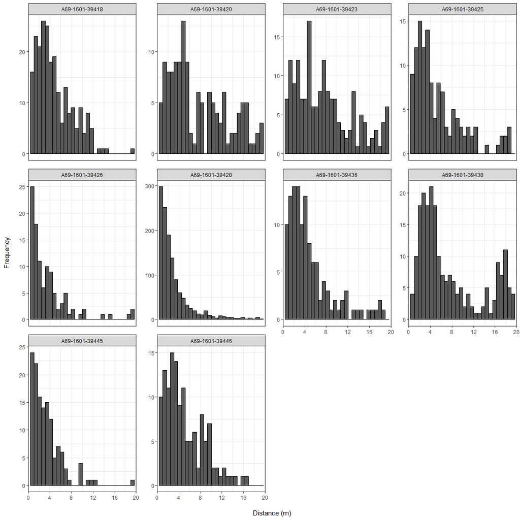

```r
ggplot(ab.res.final,aes(DISTANCE)) +
  geom_histogram(bins = 30,colour = "black") + facet_wrap(~DETECTEDID,scale="free_y") +
  scale_x_continuous("\nDistance (m)",limits=c(0,max.DIST),breaks = seq(0,max.DIST,max.DIST/5),expand=c(0,0)) +
  scale_y_continuous("Frequency\n") +
    # scale_y_continuous("Frequency\n",limits = c(0,800),breaks = seq(0,800,200),expand=c(0,0)) +
  theme_bw() +
  theme(panel.spacing=unit(1, "lines"))
```

## Sync tag data

### Sync tag detections over time

Was sync tag A69-9002-16318 only deployed during Week 15-ish? There is a large data gap in the first third of the time series. The increasing pattern of detections, with regular spikes, is a bit suspicious. I’ll have to look into that.

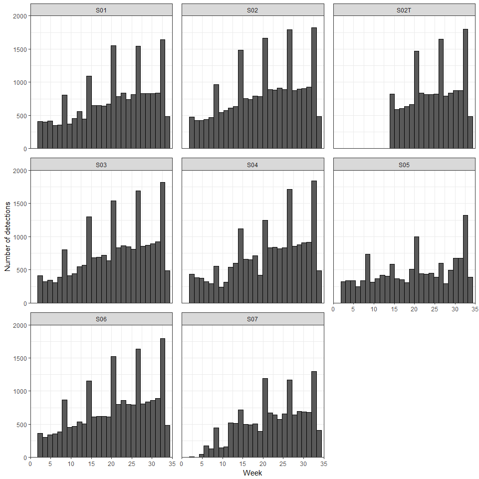

```r
ggplot(sync.res,aes(CUT)) + geom_histogram(colour='black') +
  scale_x_continuous("Week",breaks = seq(0,35,5),limits = c(0,35),expand=c(0,0)) +
  scale_y_continuous("Number of detections",breaks = seq(0,2000,500),limits = c(0,2000),expand = c(0,0)) +
  facet_wrap(~TRANSMITTER) +
  theme_bw() +
  theme(panel.spacing=unit(1, "lines"))
```

### Sync tag movement distances between detections

Interestingly, sync tag momements are often quite large. **NOTE differenes in y-axis scale.**

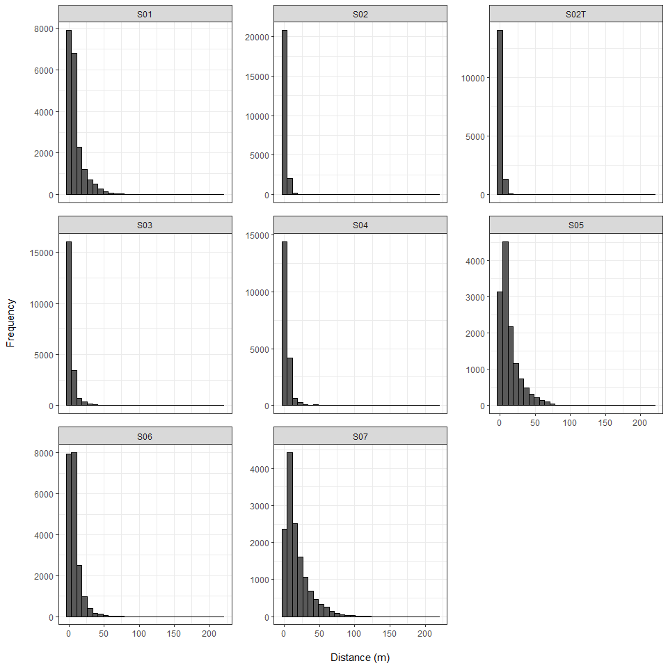

```r
ggplot() +
  geom_histogram(data = sync.res,aes(DISTANCE),colour="black") + facet_wrap(~TRANSMITTER,scales="free_y") +
    scale_x_continuous("\nDistance (m)") +
    # scale_x_continuous("\nDistance (m)",limits = c(0,250),expand = c(0,0)) +
    scale_y_continuous("Frequency\n") +
      # scale_y_continuous("Frequency\n",limits = c(0,10000),expand = c(0,0)) +
  theme_bw() +
  theme(panel.spacing=unit(1, "lines"))
```

# Spatial plots

## Abalone tag data

### Plot of pinto abalone detection locations - UNFILTERED

Pinto abalone detection locations mapped relative to the hydrophone stations and symbolized by horizontal position error.

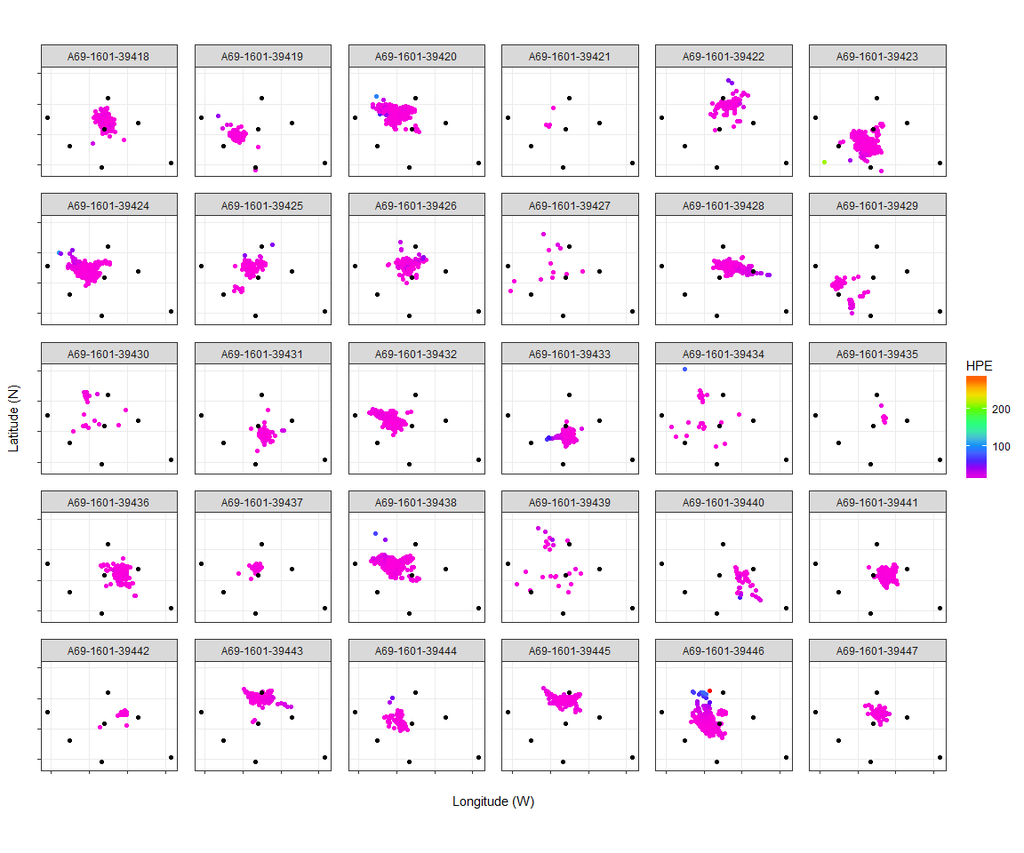

```r
ggplot() +
  geom_point(data = ab.res,aes(LON,LAT,colour=HPE)) +
  scale_colour_gradientn(colours=rev(rainbow(7))) +
  geom_point(data=station.data,aes(LON,LAT)) +
  facet_wrap(~DETECTEDID) +
  xlab("\nLongitude (W)") + ylab("Latitude (N)\n") +
  theme_bw() + theme(plot.background=element_blank(),
                     axis.text.x = element_blank(),
                     axis.text.y = element_blank(),
                     panel.spacing=unit(1, "lines")) +
  coord_map(projection = "azequidistant")
```

### Plot of pinto abalone detection locations - FILTERED

Pinto abalone detection locations mapped relative to the hydrophone stations and symbolized by horizontal position error. Data have been filtered by HPE (HPE; threshold = 7.5) and distance (threshold = 20).

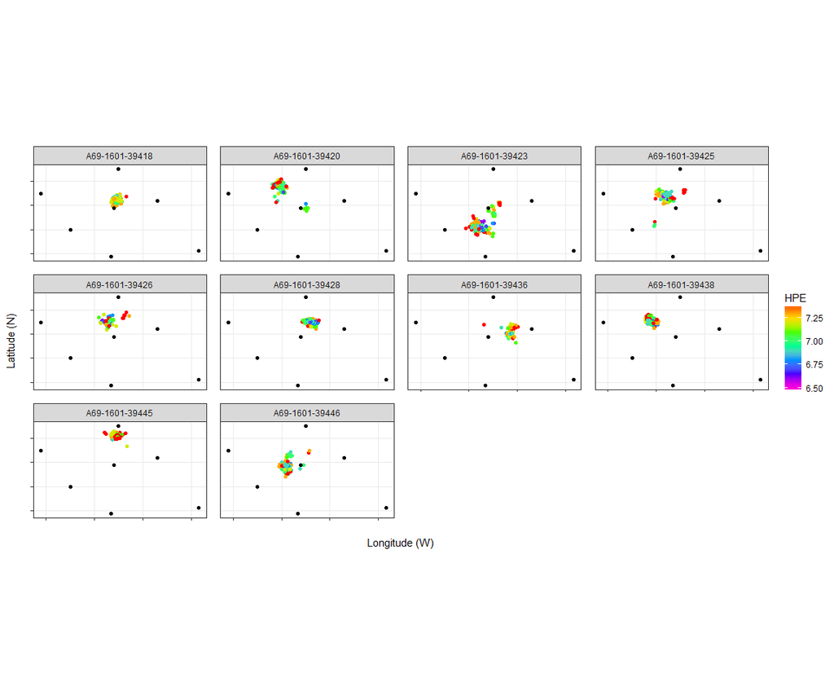

```r
ggplot() +
  geom_point(data = ab.res.final,aes(LON,LAT,colour=HPE)) +
  scale_colour_gradientn(colours=rev(rainbow(7))) +
  geom_point(data=station.data,aes(LON,LAT)) +
  facet_wrap(~DETECTEDID) +
  xlab("\nLongitude (W)") + ylab("Latitude (N)\n") +
  theme_bw() + theme(plot.background=element_blank(),
                     axis.text.x = element_blank(),
                     axis.text.y = element_blank(),
                     panel.spacing=unit(1, "lines")) +
  coord_map(projection = "azequidistant")
```

## Sync tag data

### Plot of sync tag detection locations - UNFILTERED

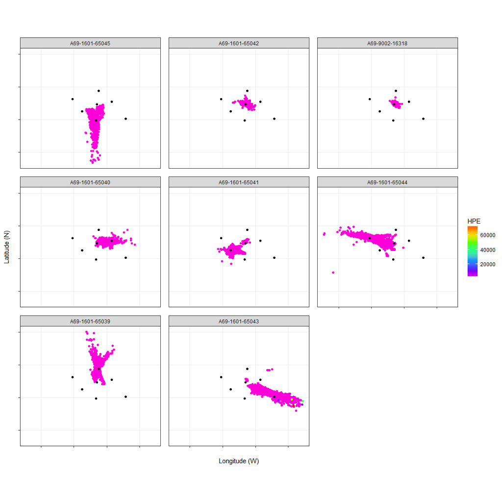

```r
ggplot() +
  geom_point(data = sync.res,aes(LON,LAT,colour=HPE)) +
  scale_colour_gradientn(colours=rev(rainbow(7))) +
  geom_point(data=station.data,aes(LON,LAT)) +
  facet_wrap(~DETECTEDID) +
  xlab("\nLongitude (W)") + ylab("Latitude (N)\n") +
  theme_bw() + theme(plot.background=element_blank(),
                     axis.text.x = element_blank(),
                     axis.text.y = element_blank(),
                     panel.spacing=unit(1, "lines")) +
  coord_map(projection = "azequidistant")
```

### Plot of sync tag detection locations - FILTERED

Sync tag detection locations mapped relative to the hydrophone stations and symbolized by horizontal position error. Data have been filtered by HPE (HPE; threshold = 7.5) and distance (threshold = 20).

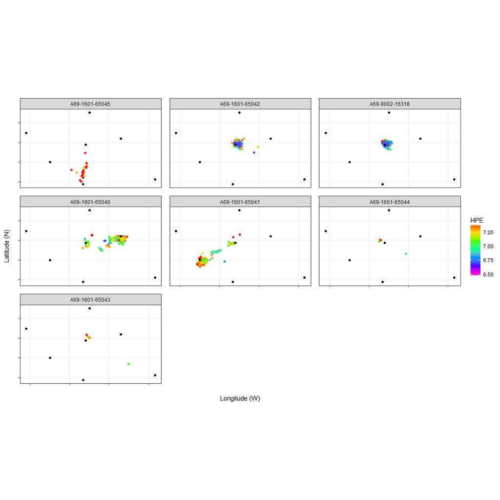

```r
ggplot() +
  geom_point(data = sync.res.sub,aes(LON,LAT,colour=HPE)) +
  scale_colour_gradientn(colours=rev(rainbow(7))) +
  geom_point(data=station.data,aes(LON,LAT)) +
  facet_wrap(~DETECTEDID) +
  xlab("\nLongitude (W)") + ylab("Latitude (N)\n") +
  theme_bw() + theme(plot.background=element_blank(),
                     axis.text.x = element_blank(),
                     axis.text.y = element_blank(),
                     panel.spacing=unit(1, "lines")) +
  coord_map(projection = "azequidistant")
```

# Spatio-temporal plots

## Abalone tag data

### Plot of pinto abalone detection locations by individual and week

Each panel shows data from an individual abalone, symbolized by week.

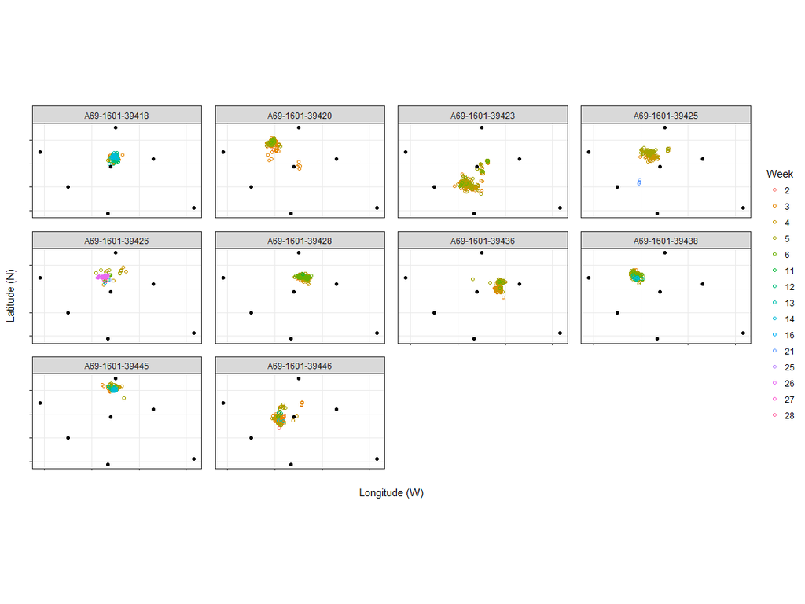

```r
ggplot(ab.res.final,aes(LON,LAT)) +
  geom_point(aes(colour=factor(CUT)),shape=21) +
  scale_colour_discrete(name="Week") +
  geom_point(data=station.data,aes(LON,LAT)) +
  facet_wrap(~DETECTEDID) +
  xlab("\nLongitude (W)") + ylab("Latitude (N)\n") +
  theme_bw() + theme(plot.background=element_blank(),
                     axis.text.x = element_blank(),
                     axis.text.y = element_blank(),
                     panel.spacing=unit(1, "lines")) +
  coord_map(projection = "azequidistant")
```

### Plot of pinto abalone detection locations by week

Each panel shows data from all abalone during each week of the study. Apparently very few animals remained in the system after Week 15 or 16.

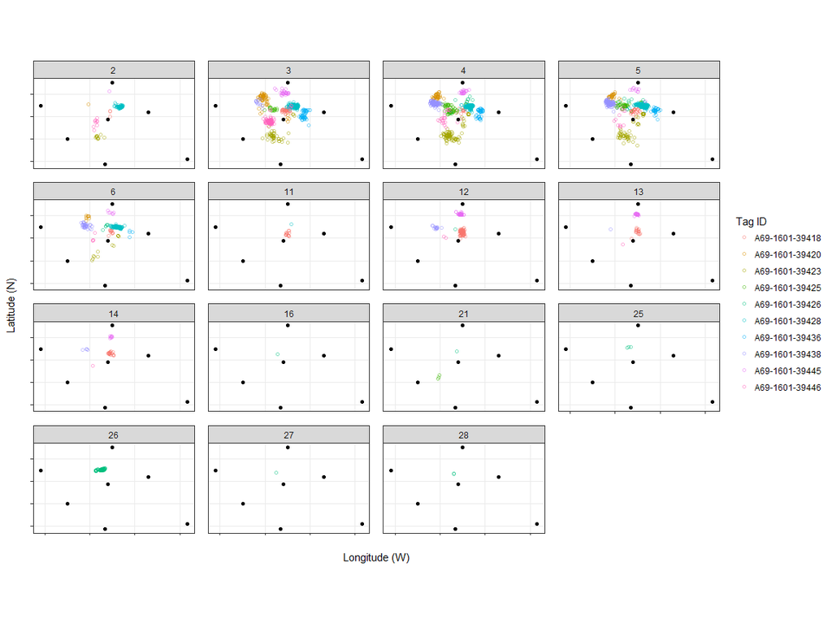

```r
ggplot(ab.res.final,aes(LON,LAT)) +
  geom_point(aes(colour=factor(DETECTEDID)),shape=21,alpha=0.5) +
  scale_colour_discrete(name="Tag ID") +
  geom_point(data=station.data,aes(LON,LAT)) +
  facet_wrap(~CUT) +
  xlab("\nLongitude (W)") + ylab("Latitude (N)\n") +
  theme_bw() + theme(plot.background=element_blank(),
                     axis.text.x = element_blank(),
                     axis.text.y = element_blank(),
                     panel.spacing=unit(1, "lines")) +
  coord_map(projection = "azequidistant")
```

# Convex hull plots

## Abalone tag data

### Convex hulls around pinto abalone detections

Each panel shows the convex hull that encapsulates all filtered abalone tag detections for each individual.

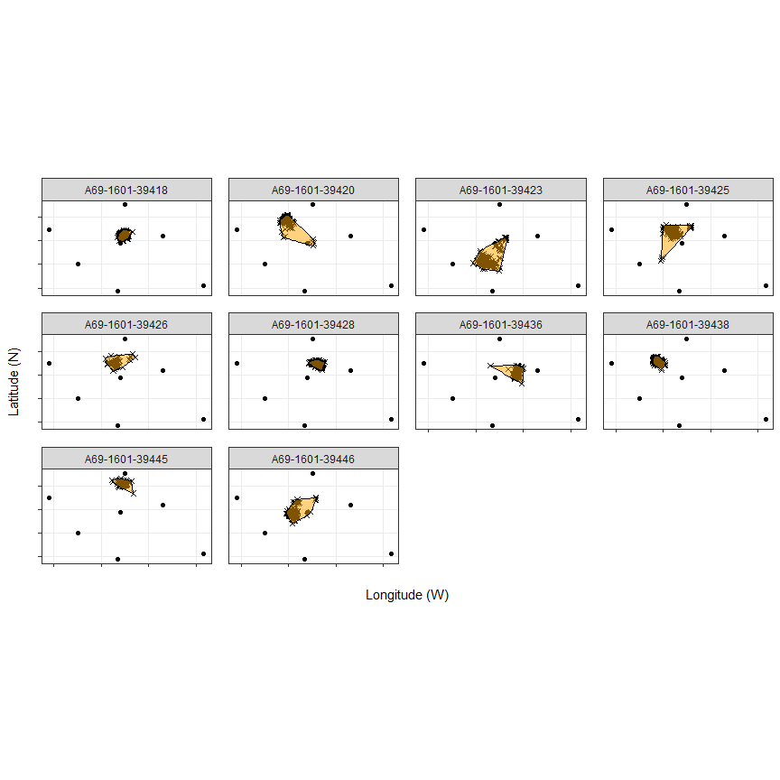

```r
# summarize tags by number of detections
tag.summ <- ddply(ab.res.final,.(DETECTEDID),summarise,
                  n = length(LON))
# # select tags with > 150 detections
# good.tags <-select(filter(tag.summ,n>=150),DETECTEDID)
# function for creating hulls
find_hull <- function(df) df[chull(df$LON, df$LAT), ]
# create hulls
hulls_all <- ddply(ab.res.final, "DETECTEDID", find_hull)
# plot all hulls
ggplot(ab.res.final,aes(LON,LAT)) +
  geom_point(colour = 'black',shape=4) +
  geom_point(data=station.data,aes(LON,LAT)) +
  geom_polygon(data = hulls_all, colour = "black",fill='orange',alpha = 0.5) +
  facet_wrap(~DETECTEDID) +
  xlab("\nLongitude (W)") + ylab("Latitude (N)\n") +
  theme_bw() + theme(plot.background=element_blank(),
                     axis.text.x = element_blank(),
                     axis.text.y = element_blank(),
                     panel.spacing=unit(1, "lines")) +
  coord_map(projection = "azequidistant")
```

### Convex hulls around pinto abalone detections - ALL

Convex hulls that encapsulate each filtered abalone tag detection are shown in one plot. For clarity, only data from abalone tags with a minimum of 100 detections are shown. Apparently few, if any, abalone were observed in the SE portion of the study site.

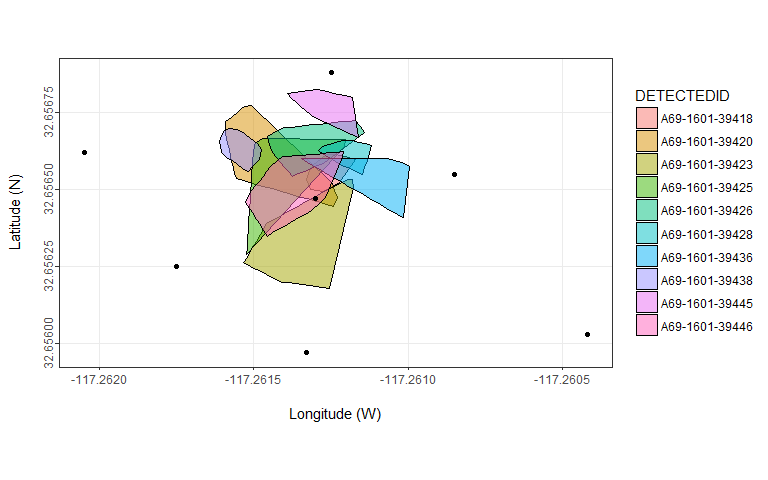

```r
ggplot() +
  geom_polygon(data=hulls_all,aes(LON,LAT,group=DETECTEDID,fill=DETECTEDID),alpha = 0.5,colour='black') +
  geom_point(data=station.data,aes(LON,LAT)) +
  xlab("\nLongitude (W)") + ylab("Latitude (N)\n") +
  theme_bw() + theme(plot.background=element_blank(),
                     axis.text.y = element_text(angle = 90, hjust=0.5),
                     panel.spacing=unit(1, "lines")) +
  coord_map(projection = "azequidistant")
```

```r
ggsave(filename = "../Figs/fig_convex_hulls_ALL.png")
```

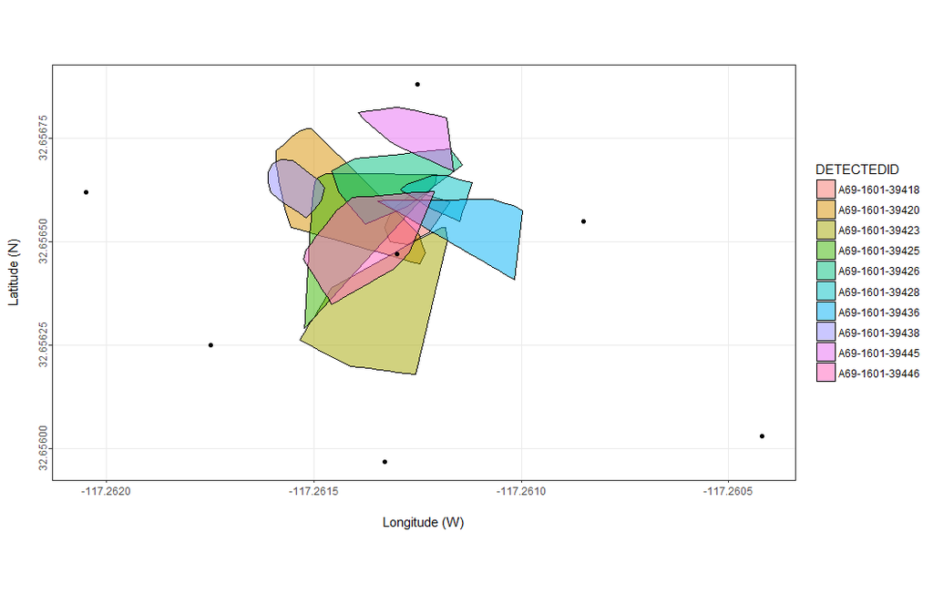

```r
ggplot() +
  geom_polygon(data=hulls_all,aes(LON,LAT,group=DETECTEDID,fill=DETECTEDID),alpha = 0.5,colour='black') +
  geom_point(data=station.data,aes(LON,LAT)) +
  xlab("\nLongitude (W)") + ylab("Latitude (N)\n") +
  theme_bw() + theme(plot.background=element_blank(),
                     axis.text.y = element_text(angle = 90, hjust=0.5),
                     panel.spacing=unit(1, "lines")) +
  coord_map(projection = "azequidistant")
```

```r
ggsave(filename = "../Figs/fig_convex_hulls_ALL.png",height = 7,width = 12)
```

### Density contours around pinto abalone detections

Each panel shows the density contours (2D kernel density estimation; see http://docs.ggplot2.org/current/geom_density_2d.html) around filtered abalone tag detections for each individual.

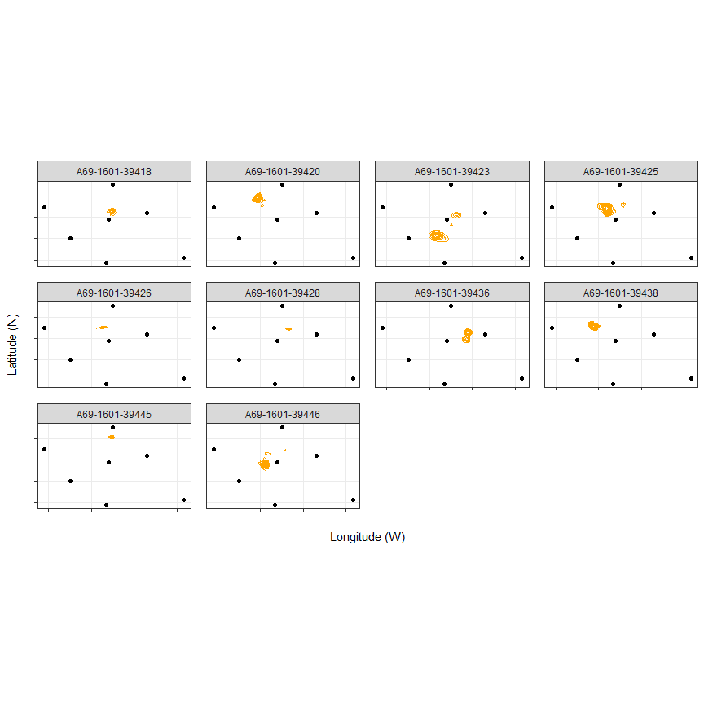

```r
ggplot(ab.res.final,aes(x = LON,y = LAT)) +
  geom_density_2d(colour='orange') +
  geom_point(data=station.data,aes(LON,LAT)) +
  facet_wrap(~DETECTEDID) +
  xlab("\nLongitude (W)") + ylab("Latitude (N)\n") +
  theme_bw() + theme(plot.background=element_blank(),
                     axis.text.x = element_blank(),
                     axis.text.y = element_blank(),
                     panel.spacing=unit(1, "lines")) +
  coord_map(projection = "azequidistant")
```

### Density contours around pinto abalone detections - ALL

Density contours for all filtered abalone tag detection in one plot. For clarity, only data from abalone tags with a minimum of 100 detections are shown. Apparently few, if any, abalone were observed in the SE portion of the study site.

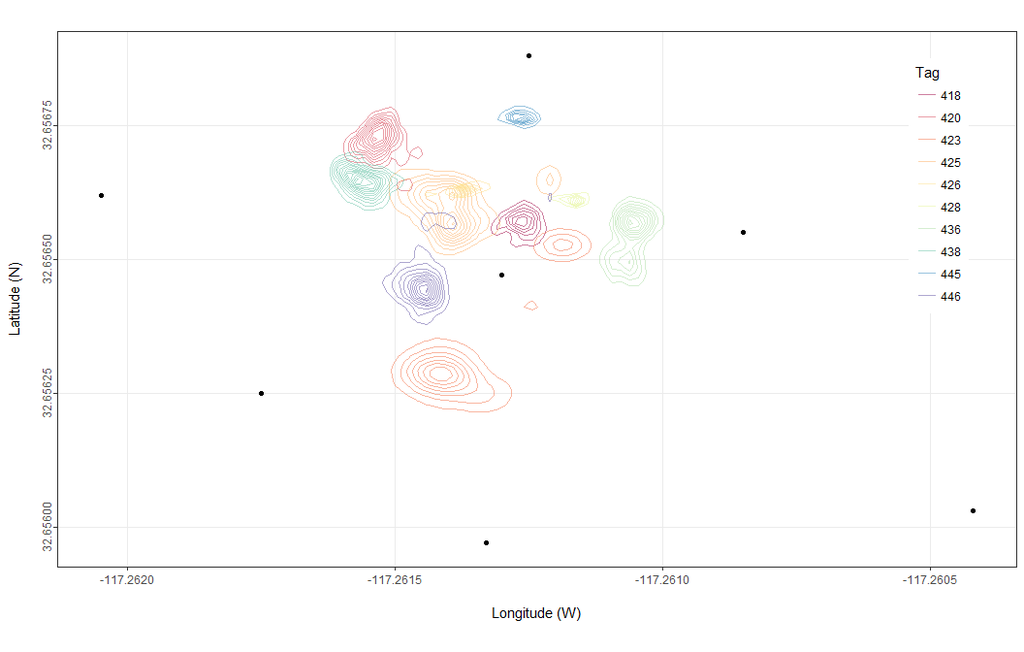

```r
ggplot(ab.res.final,aes(x = LON,y = LAT)) +
  geom_density_2d(aes(colour = tag),alpha=0.5) +
  geom_point(data=station.data,aes(LON,LAT)) +
  scale_colour_brewer(name="Tag",palette="Spectral") +
  xlab("\nLongitude (W)") + ylab("Latitude (N)\n") +
  theme_bw() + theme(plot.background=element_blank(),
                     axis.text.y = element_text(angle = 90, hjust=0.5),
                     panel.spacing=unit(1, "lines"),
                     legend.position = c(0.95,0.95),
                     legend.justification = c(1,1)) +
  coord_map(projection = "azequidistant")
```

```r
ggsave(filename = "../Figs/fig_tag_density_contours_ALL.png",height = 7,width = 12)
```

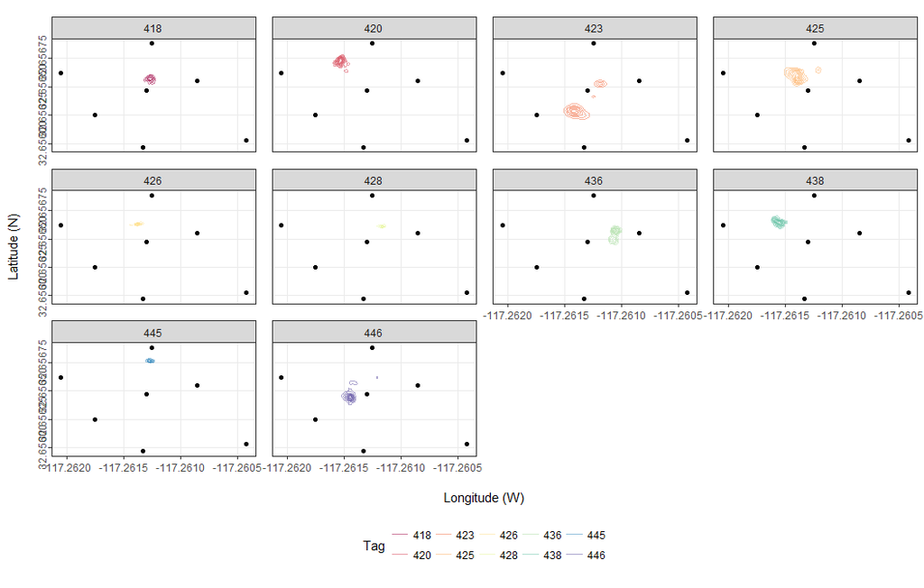

```r
ggplot(ab.res.final,aes(x = LON,y = LAT)) +
  geom_density_2d(aes(colour = tag),alpha=0.5) +
  geom_point(data=station.data,aes(LON,LAT)) +
  facet_wrap(~tag) +
  scale_colour_brewer(name="Tag",palette="Spectral") +
  xlab("\nLongitude (W)") + ylab("Latitude (N)\n") +
  theme_bw() + theme(plot.background=element_blank(),
                     axis.text.y = element_text(angle = 90, hjust=0.5),
                     panel.spacing=unit(1, "line"),
                     legend.position = 'bottom') +
  coord_map(projection = "azequidistant")
```

```r
ggsave(filename = "../Figs/fig_tag_density_contours_ALL_facet.png",height = 7,width = 12)
```